# 02_fpl_predict_random_forest

```python
import pandas as pd
import numpy as np
from pathlib import Path
import matplotlib.pyplot as plt
from sklearn.preprocessing import LabelEncoder
from sklearn.feature_extraction import DictVectorizer
from sklearn.ensemble import RandomForestRegressor
from sklearn.impute import SimpleImputer
from sklearn.inspection import plot_partial_dependence
from dtreeviz.trees import *
import scipy as sp
from scipy.cluster import hierarchy as hc
from helpers import *
```

```python
# path to project directory
path = Path('./')
```

```python
# read in training dataset
train_df = pd.read_csv(path/'data/train_v5.csv', index_col=0, dtype={'season':str})
```

## Random Forest

Random Forest is an ensemble tree-based predictive algorithm. In this case we will be using it for regression - we want to predict a continuous number, predicted points, for each player each game. It works by training many separate decision trees, each using a subset of the training data, and outputs the average prediction across all trees.

Applying it to a time series problem, where metrics from recent time periods can be predicitve, requires us to add in window features (e.g. points scored last gameweek). These are created using the player_lag_features function from 00_fpl_features.

```python
# add a bunch of player lag features
lag_train_df, team_lag_vars = team_lag_features(train_df, ['total_points'], ['all', 1, 2, 3, 4, 5, 10])
lag_train_df, player_lag_vars = player_lag_features(lag_train_df, ['total_points'], ['all', 1, 2, 3, 4, 5, 10])
```

Similar to the simple model, we'll set the validation period to be gameweeks 20-25 of the 2019/20 season - the model will be trained on all data prior to that period. This time however, we'll be using some additional features: the season, gameweek, player position, home/away, and both teams, as well as all the lagging features we created above.

```python
# set validaton point/length and categorical/continuous variables
valid_season = '1920'
valid_gw = 20
valid_len = 6
cat_vars = ['season', 'position', 'was_home', 'team', 'opponent_team']
cont_vars = ['gw', 'minutes']
dep_var = ['total_points']
```

Some of the features have an order (2019/20 season is after 2019 season) whereas others do not (position). We can set this in the data where appropriate using an ordered category (e.g. 1617 < 1718 < 1819 < 1920 < 2021).

```python
# we want to set gw and season as ordered categorical variables
# need lists with ordered categories
ordered_gws = list(range(1,39))
ordered_seasons = ['1617', '1718', '1819', '1920', '2021']

# set as categories with correct order
lag_train_df['gw'] = lag_train_df['gw'].astype('category')
lag_train_df['season'] = lag_train_df['season'].astype('category')

lag_train_df['gw'].cat.set_categories(ordered_gws, ordered=True, inplace=True)
lag_train_df['season'].cat.set_categories(ordered_seasons, ordered=True, inplace=True)
```

```python
lag_train_df['season']
```

```
0        1617
1        1617
2        1617
3        1617
4        1617
         ...
91950    2021
91951    2021
91952    2021
91953    2021
91954    2021
Name: season, Length: 91955, dtype: category
Categories (5, object): ['1617' < '1718' < '1819' < '1920' < '2021']
```

And now we can go ahead and create our training and validation sets using the function we definted in the last notebook.

```python
# create dataset with adjusted post-validation lag numbers
train_valid_df, train_idx, valid_idx = create_lag_train(lag_train_df,
                                                      cat_vars, cont_vars,
                                                      player_lag_vars, team_lag_vars, dep_var,
                                                      valid_season, valid_gw, valid_len)
```

The way we calculate our lag features means that there will be null values in our dataset. This will cause an error when using random forest in scikit learn, so we will set them all to zero for now (although note that this may not be the best fill strategy).

```python
lag_train_df[~np.isfinite(lag_train_df['total_points_pg_last_1'])]
```

|  | player | gw | position | minutes | team | opponent_team | relative_market_value_team | relative_market_value_opponent_team | was_home | total_points | ... | total_points_last_2 | total_points_pg_last_2 | total_points_last_3 | total_points_pg_last_3 | total_points_last_4 | total_points_pg_last_4 | total_points_last_5 | total_points_pg_last_5 | total_points_last_10 | total_points_pg_last_10 |
| --- | --- | --- | --- | --- | --- | --- | --- | --- | --- | --- | --- | --- | --- | --- | --- | --- | --- | --- | --- | --- | --- |
| 0 | Aaron_Cresswell | 1 | 2 | 0 | West Ham United | Chelsea | NaN | NaN | False | 0 | ... | 0.0 | NaN | 0.0 | NaN | 0.0 | NaN | 0.0 | NaN | 0.0 | NaN |
| 1 | Aaron_Lennon | 1 | 3 | 15 | Everton | Tottenham Hotspur | NaN | NaN | True | 1 | ... | 0.0 | NaN | 0.0 | NaN | 0.0 | NaN | 0.0 | NaN | 0.0 | NaN |
| 2 | Aaron_Ramsey | 1 | 3 | 60 | Arsenal | Liverpool | NaN | NaN | True | 2 | ... | 0.0 | NaN | 0.0 | NaN | 0.0 | NaN | 0.0 | NaN | 0.0 | NaN |
| 3 | Abdoulaye_Doucouré | 1 | 3 | 0 | Watford | Southampton | NaN | NaN | False | 0 | ... | 0.0 | NaN | 0.0 | NaN | 0.0 | NaN | 0.0 | NaN | 0.0 | NaN |
| 4 | Abdul Rahman_Baba | 1 | 2 | 0 | Chelsea | West Ham United | NaN | NaN | True | 0 | ... | 0.0 | NaN | 0.0 | NaN | 0.0 | NaN | 0.0 | NaN | 0.0 | NaN |
| ... | ... | ... | ... | ... | ... | ... | ... | ... | ... | ... | ... | ... | ... | ... | ... | ... | ... | ... | ... | ... | ... |
| 91946 | Yan_Valery | 3 | 2 | 0 | Southampton | Burnley | 0.483027 | 0.356232 | False | 0 | ... | 0.0 | NaN | 0.0 | NaN | 0.0 | NaN | 0.0 | NaN | 1.0 | 2.0 |
| 91948 | Yoshinori_Muto | 3 | 4 | 0 | Newcastle United | Tottenham Hotspur | 0.614499 | 1.784963 | False | 0 | ... | 0.0 | NaN | 0.0 | NaN | 0.0 | NaN | 0.0 | NaN | 1.0 | 15.0 |
| 91951 | Zack_Steffen | 3 | 1 | 0 | Manchester City | Leicester City | 2.373652 | 1.058004 | True | 0 | ... | 0.0 | NaN | 0.0 | NaN | 0.0 | NaN | 0.0 | NaN | 0.0 | NaN |
| 91952 | Zeze Steven_Sessegnon | 3 | 2 | 0 | Fulham | Aston Villa | 0.362385 | 0.583273 | True | 0 | ... | 0.0 | NaN | 0.0 | NaN | 0.0 | NaN | 0.0 | NaN | 0.0 | NaN |
| 91954 | Ørjan_Nyland | 3 | 1 | 0 | Aston Villa | Fulham | 0.583273 | 0.362385 | False | 0 | ... | 0.0 | NaN | 0.0 | NaN | 0.0 | NaN | 0.0 | NaN | 6.0 | 2.0 |

49615 rows × 88 columns

```python
# imp = SimpleImputer(missing_values=np.nan, strategy='mean')
# need to think about imputing NaN instead of setting to zero
# imp.fit(X_train[team_lag_vars + player_lag_vars])
train_valid_df[team_lag_vars + player_lag_vars] = train_valid_df[team_lag_vars + player_lag_vars].fillna(0)
```

The random forest regressor will only take numbers as inputs, so we need to transform our caterogical features into a format that the random forest regressor object will be able to use, numbers instead of strings in one or more columns.

```python
# split out dependent variable
X, y = train_valid_df[cat_vars + cont_vars + team_lag_vars + player_lag_vars].copy(), train_valid_df[dep_var].copy()
```

```python
# since position is categorical, it should be a string
X['position'] = X['position'].apply(str)

# need to transform season
enc = LabelEncoder()
X['season'] = enc.fit_transform(X['season'])
X_dict = X.to_dict("records")

# Create the DictVectorizer object: dv
dv = DictVectorizer(sparse=False, separator='_')

# Apply dv on df: df_encoded
X_encoded = dv.fit_transform(X_dict)

X_df = pd.DataFrame(X_encoded, columns=dv.feature_names_)
```

For example, season is now represented by a number (0 -> 2016/17, 1 -> 2017/18, etc.) in a single column, and position is represented by a 1 or 0 in multiple columns.

```python
X_df[['season', 'position_1', 'position_2', 'position_3', 'position_4']]
```

|  | season | position_1 | position_2 | position_3 | position_4 |
| --- | --- | --- | --- | --- | --- |
| 0 | 0.0 | 0.0 | 1.0 | 0.0 | 0.0 |
| 1 | 0.0 | 0.0 | 0.0 | 1.0 | 0.0 |
| 2 | 0.0 | 0.0 | 0.0 | 1.0 | 0.0 |
| 3 | 0.0 | 0.0 | 0.0 | 1.0 | 0.0 |
| 4 | 0.0 | 0.0 | 1.0 | 0.0 | 0.0 |
| ... | ... | ... | ... | ... | ... |
| 82049 | 3.0 | 0.0 | 0.0 | 0.0 | 1.0 |
| 82050 | 3.0 | 0.0 | 0.0 | 1.0 | 0.0 |
| 82051 | 3.0 | 0.0 | 0.0 | 1.0 | 0.0 |
| 82052 | 3.0 | 0.0 | 1.0 | 0.0 | 0.0 |
| 82053 | 3.0 | 1.0 | 0.0 | 0.0 | 0.0 |

82054 rows × 5 columns

```python
X_df.columns
```

```
Index(['gw', 'minutes', 'minutes_last_1', 'minutes_last_10', 'minutes_last_2',
       'minutes_last_3', 'minutes_last_4', 'minutes_last_5',
       'minutes_last_all', 'opponent_team_Arsenal',
       'opponent_team_Aston Villa', 'opponent_team_Bournemouth',
       'opponent_team_Brighton and Hove Albion', 'opponent_team_Burnley',
       'opponent_team_Cardiff City', 'opponent_team_Chelsea',
       'opponent_team_Crystal Palace', 'opponent_team_Everton',
       'opponent_team_Fulham', 'opponent_team_Huddersfield Town',
       'opponent_team_Hull City', 'opponent_team_Leicester City',
       'opponent_team_Liverpool', 'opponent_team_Manchester City',
       'opponent_team_Manchester United', 'opponent_team_Middlesbrough',
       'opponent_team_Newcastle United', 'opponent_team_Norwich',
       'opponent_team_Sheffield United', 'opponent_team_Southampton',
       'opponent_team_Stoke City', 'opponent_team_Sunderland',
       'opponent_team_Swansea City', 'opponent_team_Tottenham Hotspur',
       'opponent_team_Watford', 'opponent_team_West Bromwich Albion',
       'opponent_team_West Ham United',
       'opponent_team_Wolverhampton Wanderers', 'position_1', 'position_2',
       'position_3', 'position_4', 'season', 'team_Arsenal',
       'team_Aston Villa', 'team_Bournemouth', 'team_Brighton and Hove Albion',
       'team_Burnley', 'team_Cardiff City', 'team_Chelsea',
       'team_Crystal Palace', 'team_Everton', 'team_Fulham',
       'team_Huddersfield Town', 'team_Hull City', 'team_Leicester City',
       'team_Liverpool', 'team_Manchester City', 'team_Manchester United',
       'team_Middlesbrough', 'team_Newcastle United', 'team_Norwich',
       'team_Sheffield United', 'team_Southampton', 'team_Stoke City',
       'team_Sunderland', 'team_Swansea City', 'team_Tottenham Hotspur',
       'team_Watford', 'team_West Bromwich Albion', 'team_West Ham United',
       'team_Wolverhampton Wanderers', 'total_points_pg_last_1',
       'total_points_pg_last_10', 'total_points_pg_last_2',
       'total_points_pg_last_3', 'total_points_pg_last_4',
       'total_points_pg_last_5', 'total_points_pg_last_all',
       'total_points_team_pg_last_1', 'total_points_team_pg_last_10',
       'total_points_team_pg_last_10_opponent',
       'total_points_team_pg_last_1_opponent', 'total_points_team_pg_last_2',
       'total_points_team_pg_last_2_opponent', 'total_points_team_pg_last_3',
       'total_points_team_pg_last_3_opponent', 'total_points_team_pg_last_4',
       'total_points_team_pg_last_4_opponent', 'total_points_team_pg_last_5',
       'total_points_team_pg_last_5_opponent', 'total_points_team_pg_last_all',
       'total_points_team_pg_last_all_opponent', 'was_home'],
      dtype='object')
```

Let's now split out our training (everything prior to the validation gameweek) and validation (6 gameweeks from the validation gameweek).

```python
# split out training and validation sets
X_train = X_df.iloc[train_idx]
y_train = y.iloc[train_idx]
X_test = X_df.iloc[valid_idx]
y_test = y.iloc[valid_idx]
```

We can now create the RandomForestRegessor with set parameters, train using the training data, and look at the error on the validation set.

```python
def rf(xs, y, n_estimators=40, max_samples=50_000,
       max_features=0.5, min_samples_leaf=5, **kwargs):
    return RandomForestRegressor(n_jobs=-1, n_estimators=n_estimators,
        max_samples=max_samples, max_features=max_features,
        min_samples_leaf=min_samples_leaf, oob_score=True).fit(xs, y)
```

```python
# fit training data
m = rf(X_train, y_train.values.ravel())
```

```python
# predict validation set and output mean absolute error
mae(m.predict(X_test), y_test.values.ravel())
# mae(m.predict(X_test[X_test['minutes'] > 0]), y_test[X_test['minutes'] > 0].values.ravel())
```

```
0.865911
```

Right away this looks like it's a significant improvement on the simple model, good to see. Let's go ahead and use the same approach with validation across the whole of the 2019/20 season.

```python
def rf_season(df, valid_season='1920'):
    # empty list for scores
    scores = []
    valid_len = 6

    for valid_gw in range(1,40-valid_len):
        # create dataset with adjusted post-validation lag numbers
        train_valid_df, train_idx, valid_idx = create_lag_train(df, cat_vars, cont_vars,
                                                                player_lag_vars, team_lag_vars, dep_var,
                                                                valid_season, valid_gw, valid_len)

        train_valid_df[team_lag_vars + player_lag_vars] = train_valid_df[team_lag_vars + player_lag_vars].fillna(0)

        # split out dependent variable
        X, y = train_valid_df[cat_vars + cont_vars + team_lag_vars + player_lag_vars].copy(), train_valid_df[dep_var].copy()

        # since position is categorical, it should be a string
        X['position'] = X['position'].apply(str)

        # need to transform season
        enc = LabelEncoder()
        X['season'] = enc.fit_transform(X['season'])
        X_dict = X.to_dict("records")

        # Create the DictVectorizer object: dv
        dv = DictVectorizer(sparse=False, separator='_')

        # Apply dv on df: df_encoded
        X_encoded = dv.fit_transform(X_dict)
        X_df = pd.DataFrame(X_encoded, columns=dv.feature_names_)

        # split out training and validation sets
        X_train = X_df.iloc[train_idx]
        y_train = y.iloc[train_idx]
        X_test = X_df.iloc[valid_idx]
        y_test = y.iloc[valid_idx]

        m = rf(X_train, y_train.values.ravel())
        preds, targs = m.predict(X_test), y_test.values.ravel()
        gw_mae = mae(preds, targs)
        print("GW%d MAE: %f" % (valid_gw, gw_mae))

        scores.append(gw_mae)

    return scores
```

```python
scores = rf_season(lag_train_df)
```

```
GW1 MAE: 1.077141
GW2 MAE: 1.047597
GW3 MAE: 1.045916
GW4 MAE: 0.996283
GW5 MAE: 1.001852
GW6 MAE: 1.008389
GW7 MAE: 0.975421
GW8 MAE: 0.983200
GW9 MAE: 0.962144
GW10 MAE: 0.972289
GW11 MAE: 0.964272
GW12 MAE: 0.944218
GW13 MAE: 0.960362
GW14 MAE: 0.936839
GW15 MAE: 0.916257
GW16 MAE: 0.897852
GW17 MAE: 0.881068
GW18 MAE: 0.864787
GW19 MAE: 0.862956
GW20 MAE: 0.866022
GW21 MAE: 0.874795
GW22 MAE: 0.865928
GW23 MAE: 0.889512
GW24 MAE: 0.871454
GW25 MAE: 0.860991
GW26 MAE: 0.839611
GW27 MAE: 0.854496
GW28 MAE: 0.855356
GW29 MAE: 0.826999
GW30 MAE: 0.847180
GW31 MAE: 0.839788
GW32 MAE: 0.836650
GW33 MAE: 0.815653
```

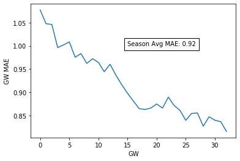

```python
plt.plot(scores)
plt.ylabel('GW MAE')
plt.xlabel('GW')
plt.text(15, 1, 'Season Avg MAE: %.2f' % np.mean(scores), bbox={'facecolor':'white', 'alpha':1, 'pad':5})
plt.show()
```

```python
# r_mse(m.predict(X_test[X_test['minutes'] > 0]), y_test[X_test['minutes'] > 0].values.ravel())
```

Looking across the whole season we see about a 10% improvement versus the simple model. Also interesting is that the performance again improves as the season progresses - this makes sense, more data about each of teams and players (particularly new ones) means improved ability to predict the next 6 gameweeks.

Let's add these validation scores to our comparison dataset.

```python
model_validation_scores = pd.read_csv(path/'charts/model_validation_scores.csv', index_col=0)
model_validation_scores['random_forest'] = scores
model_validation_scores.to_csv(path/'charts/model_validation_scores.csv')
```

A feature of the random forest algorithm is that we can see how often features are being used in trees. This will give us an indication of how important each feature is i.e. is it predictive of todal points scored. Simple models are usually better, so this also gives us a way of seeing if there are any features that are not particularly useful, and can therefore be removed.

```python
def rf_feat_importance(m, df):
    return pd.DataFrame({'cols':df.columns, 'imp':m.feature_importances_}
                       ).sort_values('imp', ascending=False)
```

```python
fi = rf_feat_importance(m, X_train)
fi[:32]
```

|  | cols | imp |
| --- | --- | --- |
| 1 | minutes | 0.401124 |
| 2 | minutes_last_1 | 0.057948 |
| 4 | minutes_last_2 | 0.053338 |
| 78 | total_points_pg_last_all | 0.043413 |
| 92 | total_points_team_pg_last_all_opponent | 0.030597 |
| 5 | minutes_last_3 | 0.026281 |
| 91 | total_points_team_pg_last_all | 0.022125 |
| 73 | total_points_pg_last_10 | 0.019638 |
| 8 | minutes_last_all | 0.019612 |
| 81 | total_points_team_pg_last_10_opponent | 0.018710 |
| 80 | total_points_team_pg_last_10 | 0.017603 |
| 90 | total_points_team_pg_last_5_opponent | 0.015438 |
| 87 | total_points_team_pg_last_4 | 0.014369 |
| 82 | total_points_team_pg_last_1_opponent | 0.014366 |
| 3 | minutes_last_10 | 0.014328 |
| 89 | total_points_team_pg_last_5 | 0.014130 |
| 84 | total_points_team_pg_last_2_opponent | 0.014042 |
| 0 | gw | 0.014018 |
| 79 | total_points_team_pg_last_1 | 0.013981 |
| 77 | total_points_pg_last_5 | 0.013816 |
| 88 | total_points_team_pg_last_4_opponent | 0.013796 |
| 83 | total_points_team_pg_last_2 | 0.013791 |
| 86 | total_points_team_pg_last_3_opponent | 0.013431 |
| 85 | total_points_team_pg_last_3 | 0.013258 |
| 75 | total_points_pg_last_3 | 0.012415 |
| 76 | total_points_pg_last_4 | 0.011685 |
| 74 | total_points_pg_last_2 | 0.011422 |
| 72 | total_points_pg_last_1 | 0.009397 |
| 7 | minutes_last_5 | 0.009116 |
| 6 | minutes_last_4 | 0.008190 |
| 93 | was_home | 0.006137 |
| 39 | position_2 | 0.005415 |

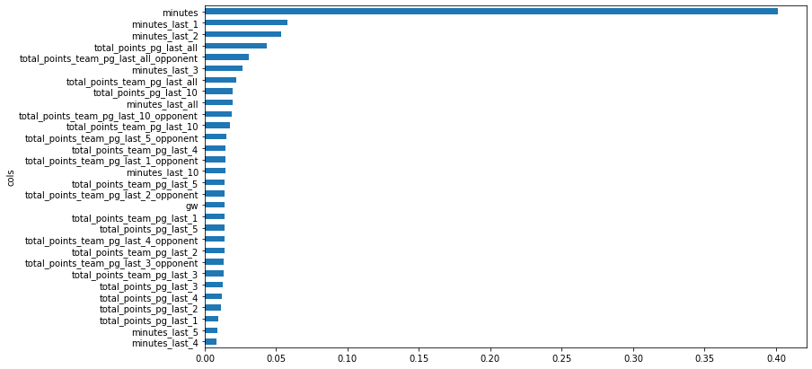

```python
def plot_fi(fi):
    return fi.plot('cols', 'imp', 'barh', figsize=(12,7), legend=False).invert_yaxis()

plot_fi(fi[:30]);
```

At the moment this algorithm is given minutes played in the gameweek so it's unsurprising that this is by far the most important feature - the more minutes a player plays, the more opportunity to score points. But strictly speaking we don't actually have this information prior to a gameweek (in practice it is estimated using previous minutes and injury status), so we can ignore it for now.

This is interesting. It seems to be saying that the amount of minutes a player has played recently and their underlying ability to score points in all of history, along with their team's and opponent team's points scoring in all of history, is most important.

Recent performance (i.e. 'form') is also important, but to a lesser extent.

It also shows that the lag features are far more useful than the categorical features such as team, opponent and position. Again not too surprising since information on these categories are already captured in the lag features.

Let's test this... we can remove anything with a feature importance of less than 0.005 and see how the model performs on the original 2019/20 week 20 validation point (going from 94 features to just 32).

```python
to_keep = fi[fi.imp>0.005].cols
len(to_keep)
```

```
32
```

```python
len(X_train.columns)
```

```
94
```

```python
X_train_imp = X_train[to_keep]
X_test_imp = X_test[to_keep]
```

```python
m = rf(X_train_imp, y_train.values.ravel())
```

```python
mae(m.predict(X_test_imp), y_test.values.ravel())
# mae(m.predict(X_train_imp), y_train.values.ravel())
```

```
0.87014
```

Very similar albeit slightly lower (less than 1% worse) than previously, and still a long way ahead of the simple model.

Continuing our thinking about improving/simplifying the model features, we can also look to see if there are any similar features - quite often we will find that some features are so similar that some of them may be redundant.

The following function determines the similarity between columns in a dataset and visualises it using a dendrogram.

```python
def cluster_columns(df, figsize=(10,6), font_size=12):
    corr = np.round(sp.stats.spearmanr(df).correlation, 4)
    corr_condensed = hc.distance.squareform(1-corr)
    z = hc.linkage(corr_condensed, method='average')
    fig = plt.figure(figsize=figsize)
    hc.dendrogram(z, labels=df.columns, orientation='left', leaf_font_size=font_size)
    plt.show()
```

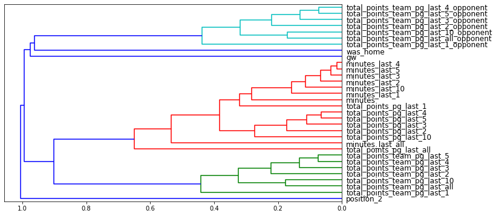

```python
cluster_columns(X_train_imp)
```

We can see that our lagging features are somewhat similar - absolutely expected since, for example, minutes_last_5 is equal to minutes_last_4 + minutes 5 games ago. They are still different enough to be of value separately, but it does make me wonder whether separating out each historic game in some way (up to a point) would be valuable.

A final useful tool we can use is partial dependency plots. These try to look at the impact of single features on the dependent variable (points scored).

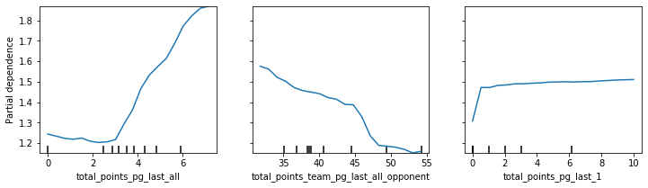

```python
fig,ax = plt.subplots(figsize=(12, 3))
plot_partial_dependence(m, X_test, ['total_points_pg_last_all',
                                    'total_points_team_pg_last_all_opponent',
                                    'total_points_pg_last_1'],
                        grid_resolution=20, ax=ax);
```

Again, these make sense. The higher a player's historic points per game (defined as 90 minutes) is, the higher we predict their score will be. Conversely, the higher their opposition's historic points per game, the harder they are as an opponent and the lower their predicted score will be.

Looking at the player's most recent game, again the higher their score, the more it will push up our prediction (the impact of their 'form'), but the relationship is far weaker than the player's underlying per minute scoring stats.

Here we just try to look at features in isolation, there will lots of interactions going on between features that improve performance. For example, a player may have a high 'total_points_pg_last_1' from the previous fixture but only played 5 minutes in total - in this case the algorithm is likely to have learned that a high 'total_points_pg_last_1' coupled with a low 'minutes_last_1' is not an indicator that the player will score higher in the next fixture.

Ok, now we can move onto the next algorithm - xgboost.